# Creating a Data Driven Dashboard

March 29, 2019

## Dashboard features

- combination of interactive and static plots displaying a specific message
- shows multiple plots that are interesting
- user interface allows various display of data
- some examples
  - [Streaming CRAN data](https://gallery.shinyapps.io/087-crandash/)
  - [Twin city bus route](https://gallery.shinyapps.io/086-bus-dashboard/)
  - [Student project on Latino Study](https://latino.shinyapps.io/Dashboard/)

## Needed package

- We need following R packages
  - `ggplot2` to create plots, `plotly` to create interactive plots
  - `shiny` to create dashboard page
  - `shinydashboard` to create dashboard layout

```r
install.packages("ggplot2", "plotly", "shiny", "shinydashboard")
```

## Basic dashboard structure

- To create a dashboard, start with the basic structure

```r
library(shiny)
library(shinydashboard)

ui <- dashboardPage(
  dashboardHeader(),
  dashboardSidebar(),
  dashboardBody()
)

server <- function(input, output) { }

shinyApp(ui, server)
```

- `ui` is user interface that allows us to design the layout
- `server` is actual programs that deals with the data and creates data plots
- finally `shinyApp()` is a function that creates the dashboard

## Dashboard Header

```r
library(shiny)
library(shinydashboard)

ui <- dashboardPage(
  dashboardHeader(title = "My Data Dashboard"),
  dashboardSidebar(),
  dashboardBody()
)

server <- function(input, output) { }

shinyApp(ui, server)
```

## Dashboard Side bar

```r
library(shiny)
library(shinydashboard)

ui <- dashboardPage(
  dashboardHeader(title = "My Data Dashboard"),
  dashboardSidebar(
    sidebarMenu(
      menuItem("My control Center", tabName = "control",
               icon = icon("dashboard")),
      menuItem("My county crime", tabName = "countyCrime",
               icon = icon("th"))
    )
  ),
  dashboardBody()
)

server <- function(input, output) { }

shinyApp(ui, server)
```

## Dashboard Body

```r
  dashboardBody(
    tabItems(
      # First tab content
      tabItem(tabName = "control",
              fluidRow(
                box(plotOutput("myPlot", height = 250)),
                box(
                  title = "Controls",
                  sliderInput("slider",
                              "Number of observations:", 1, 100, 50)
                )
              )
      ),
      # Second tab content
      tabItem(tabName = "countyCrime",
              h2("My county crime map goes here")
      )
    )
  )
```

## Dashboard server

```r
server <- function(input, output) {
  set.seed(122)
  histdata <- rnorm(500)

  output$myPlot <- renderPlot({
    data <- histdata[seq_len(input$slider)]
    hist(data)
  })
}
```

## Adding plot on second tab

- Inside dashboard body add the following codes

```r
      tabItem(tabName = "countyCrime",
              h2("My county crime map goes here"),
              fluidRow(
                box(plotOutput("myMap"), height = 450, width=500)
              )
      )
```

- Inside server add the following codes

```r
  output$myMap <- renderPlot({
    crimes <- read.csv("omaha-crimes.csv")
    load("omaps.RData") #obtained using get_map()
    ggmap(omaps) +
      geom_point(size=5, alpha = 1/2, aes(lon,lat, color=type),
                 data = crimes)
  })
```

## Adding an interactive ploltly map

- Inside siebadmenu add this code

```r
menuItem("My interactive map", tabName="map", icon= icon("air-freshener"))
```

- Inside dashboard body add the following codes, make sure it is followed by a comma from previous code

```r
      # Third tab content
      tabItem(tabName = "map",
              h2("USA interactive map goes here"),
              fluidRow(
                box(plotlyOutput("myUSA"), height = 450, width=500)
              ),
              verbatimTextOutput("click")
      )
```

## Adding an interactive ploltly map

- Inside server add the following codes

```r
  output$myUSA <- renderPlotly({
    # specify some map projection/options
    g <- list(
      scope = 'usa',
      projection = list(type = 'albers usa'),
      lakecolor = toRGB('white')
    )
    plot_ly(z = state.area, text = state.name, locations = state.abb,
            type = 'choropleth', locationmode = 'USA-states') %>%
      layout(geo = g)
  })

  output$click <- renderPrint({
    d <- event_data("plotly_click")
    if (is.null(d)) "Click on a state to view event data" else d
  })
```

## Body layout

- row based layout: `box` allows to put elements independently anywhere
  - height, width can be specified
  - background color, titles, borders can be set
  - multiple boxes can be in a row
- Column based layout: `column` allows to control specific number of columns to display
  - multiple rows can be align together under a column
  - when multiple columns are used, width can be set independently
- Mixed layout contains both row based and column based layout
- `tabBox` allows multiple tabs in a single page

## Body layout example

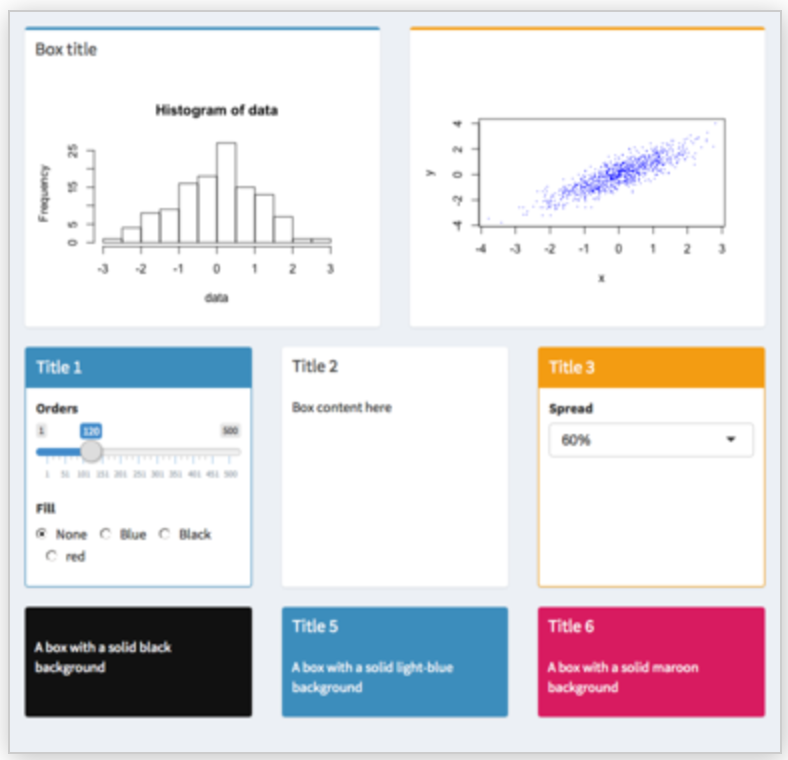

## tab Box example

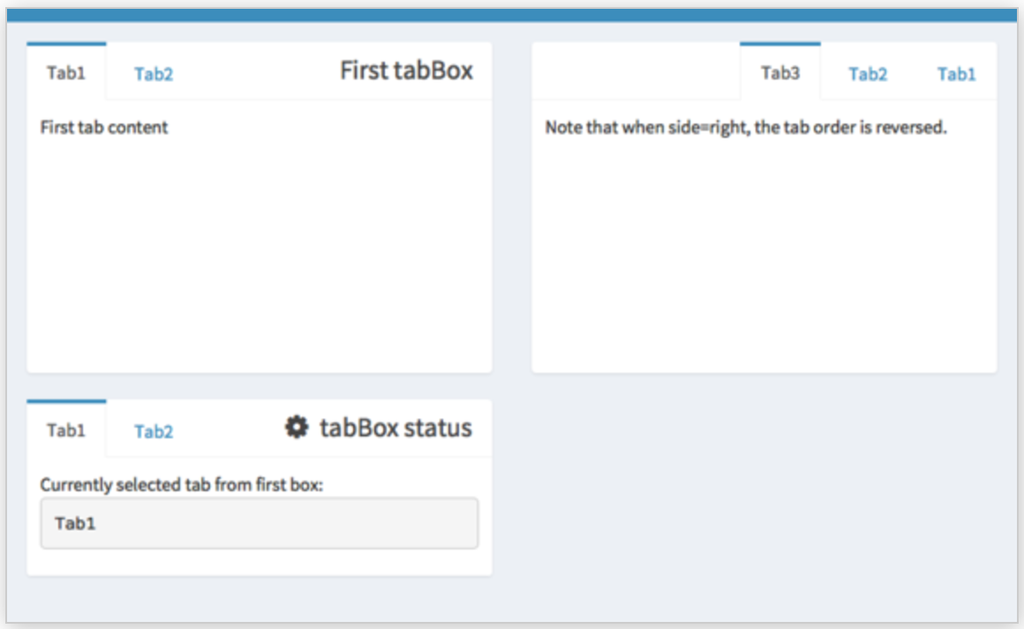

## Other Boxes

- `infoBox` is a special kind of box for displaying simple numeric or text values, with an icon

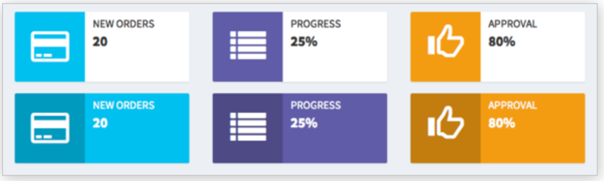

- `valueBox` is similar to infoBox, but has different appearance

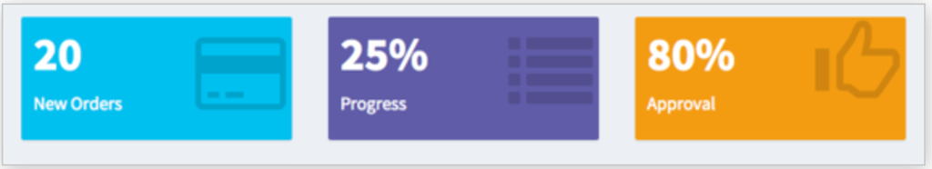

## Publishing the dashboard

- We may like to publish our dashboard for public view
- free publishing is available from rstudio
  - create an account with http://www.shinyapps.io/
  - get the token and secret of your app
  - finally on the top right side of your app, click on publish
  - it will give you a public link which will be accessible from anywhere
- To include your dashboard on another web site
  - get a public url of your dashboard from shinyApp.io (say https://latino.shinyapps.io/Dashboard/)
  - put that link inside an `iframe` tag in your HTML code
    - `<iframe src="url"></iframe>`
- Publishing with rstudio is free, but it has monthly restriction on how many hours it can be viewed.
  - may need to pay if you want your dashboard to be accessed without restriction

## Reading and references

- shinydashboard web site  
  https://rstudio.github.io/shinydashboard/index.html